# Inflação e Custo de Vida no Brasil

Uma análise exploratória do IPCA desde 2020

## Resumo

Este projeto usa dados oficiais do IBGE para investigar quais grupos de consumo mais encareceram no Brasil entre jan/2020 e set/2026 e como sua evolução se compara ao IPCA geral. No período, o IPCA geral acumulou **44,7%**, calculado pela composição das variações mensais. **Alimentação e bebidas** foi o grupo que mais encareceu (**60,7%**), enquanto **Comunicação** foi o que menos subiu (**13,8%**).

## Pergunta de pesquisa

> Quais grupos de consumo mais encareceram no Brasil desde 2020, e como sua evolução se compara à inflação geral medida pelo IPCA?

Perguntas secundárias: como a inflação mensal evoluiu, quando ocorreram os maiores picos, se há padrões sazonais aparentes, qual o peso de cada grupo e quanto cada um contribuiu para a inflação geral.

## Dados e metodologia

**Fonte:** IBGE, SIDRA, tabela 7060 (IPCA), obtida pela API oficial. **Coleta:** 19/10/2026. **Período:** jan/2020 a set/2026 (81 meses). Foram usados o índice geral e os nove grupos principais; subgrupos e itens foram usados apenas na seção de hipóteses, sem misturar níveis nas comparações principais.

Cinco conceitos distintos aparecem neste relatório:

- **Variação mensal:** quanto os preços variaram em um mês.
- **Acumulada no ano e em 12 meses:** variações mensais *compostas* dentro dessas janelas.
- **Índice de preços:** é construído como

  `Índice = 100 × (1 + v₁/100) × (1 + v₂/100) × … × (1 + vₜ/100)`

  em que *v* é a variação mensal em %. A base 100 corresponde a **dez/2019**, o mês anterior ao início da série. Um índice de 144,7 significa que os preços estão 44,7% acima da base. O **aumento acumulado** é o índice final menos 100. Variações mensais não são somadas, porque os percentuais incidem uns sobre os outros (1% + 1% resulta em 2,01%).
- **Peso:** participação do grupo na cesta de consumo (%).
- **Contribuição (em pontos percentuais, p.p.):** parcela da variação do IPCA atribuível a um grupo. Aqui é estimada de forma simplificada: `peso × variação / 100`.

**Limpeza.** Os nomes das variáveis foram padronizados e as datas e os valores, convertidos. O SIDRA usa `...` para dados que não existem; esses valores viram `NA` e não foram removidos. Eles aparecem só no acumulado em 12 meses dos primeiros 11 meses da série, que não pode ser calculado sem dados anteriores a 2020. Não há duplicatas, e as quatro variáveis têm cobertura completa para os dez agregados. Os acumulados foram recalculados a partir das variações mensais e comparados com os publicados pelo IBGE: a maior diferença absoluta em 12 meses foi de 0,03 p.p., compatível com arredondamento a duas casas.

## Análise exploratória

### Inflação mensal do IPCA geral

Variação mensal do IPCA geral (%)

| Média | Mediana | Desvio-padrão | Máxima | Mínima |
| --- | --- | --- | --- | --- |
| 0,46 | 0,43 | 0,42 | 1,62 (mar/2022) | -0,68 (jul/2022) |

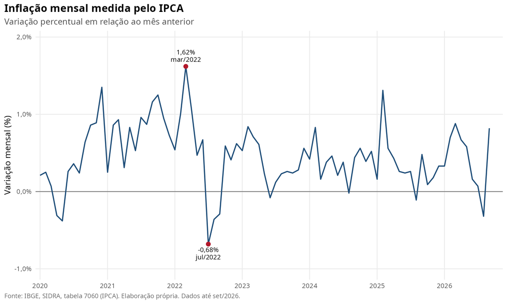

Variação mensal do IPCA geral

O gráfico mostra a trajetória mês a mês; valores abaixo de zero indicam deflação no mês. O acumulado em 12 meses atingiu seu maior valor em **abr/2022**, com **12,13%**.

10 maiores variações mensais do IPCA geral

| Mês | Variação mensal (%) | Acumulado 12 meses (%) |
| --- | --- | --- |
| mar/2022 | 1,62 | 11,30 |
| dez/2020 | 1,35 | 4,52 |
| fev/2025 | 1,31 | 5,06 |
| out/2021 | 1,25 | 10,67 |
| set/2021 | 1,16 | 10,25 |
| abr/2022 | 1,06 | 12,13 |
| fev/2022 | 1,01 | 10,54 |
| jul/2021 | 0,96 | 8,99 |
| nov/2021 | 0,95 | 10,74 |
| mar/2021 | 0,93 | 6,10 |

### Evolução dos preços por grupo

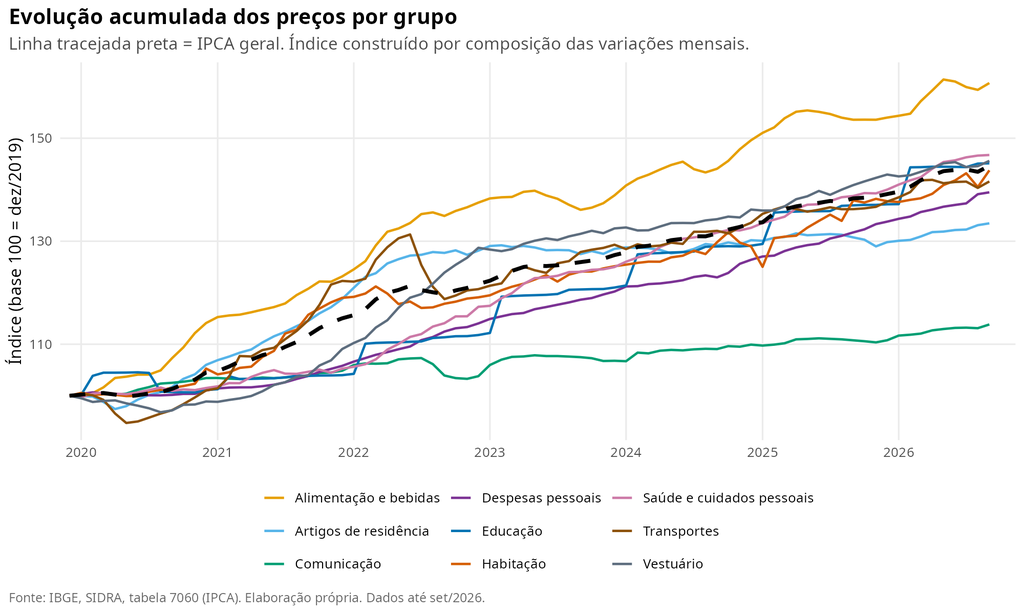

Índice de preços por grupo (base 100)

Cada linha mostra quanto os preços do grupo acumularam desde a base. Quanto mais inclinada a linha, mais rápido o grupo encareceu. A linha preta tracejada é o IPCA geral: grupos acima dela encareceram mais que a média; abaixo, menos.

### Ranking de aumento acumulado

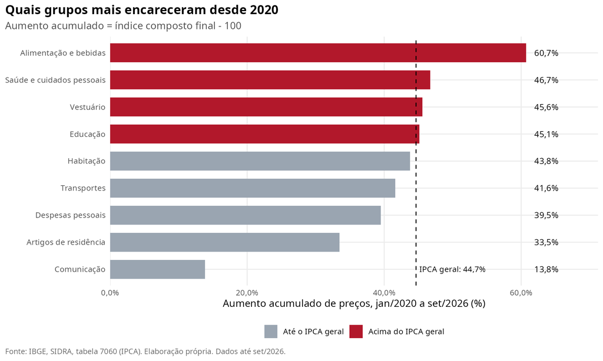

Ranking dos grupos por aumento acumulado

Aumento acumulado de jan/2020 a set/2026

| Posição | Grupo | Aumento acumulado (%) | Peso médio (%) | Acima do IPCA geral |
| --- | --- | --- | --- | --- |
| 1 | Alimentação e bebidas | 60,7 | 21,2 | Sim |
| 2 | Saúde e cuidados pessoais | 46,7 | 13,3 | Sim |
| 3 | Vestuário | 45,6 | 4,6 | Sim |
| 4 | Educação | 45,1 | 6,0 | Sim |
| 5 | Habitação | 43,8 | 15,4 | Não |
| 6 | Transportes | 41,6 | 20,6 | Não |
| 7 | Despesas pessoais | 39,5 | 10,2 | Não |
| 8 | Artigos de residência | 33,5 | 3,7 | Não |
| 9 | Comunicação | 13,8 | 5,0 | Não |

**Alimentação e bebidas** ficou na posição **1** de 9, com aumento acumulado de **60,7%**, contra **44,7%** do IPCA geral. Ao final da série, o índice de Alimentação e bebidas estava em 160,7 e o geral em 144,7. Alimentação superou o IPCA geral em 47 de 81 meses (58%). A distância entre os dois índices atingiu o máximo de 18,4 pontos em abr/2025.

### Padrões sazonais aparentes

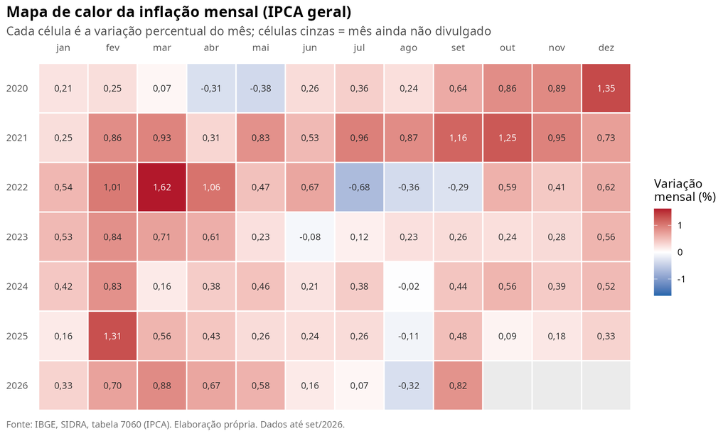

Mapa de calor da inflação mensal

Cada linha é um ano e cada coluna, um mês; vermelho indica inflação positiva, azul indica queda, e células cinza são meses ainda não divulgados. Colunas que se repetem em tom parecido ao longo dos anos sugerem sazonalidade.

Variação mensal do IPCA geral por mês do calendário

| Mês | Anos | Média (%) | Mediana (%) | Mín. (%) | Máx. (%) |
| --- | --- | --- | --- | --- | --- |
| jan | 7 | 0,35 | 0,33 | 0,16 | 0,54 |
| fev | 7 | 0,83 | 0,84 | 0,25 | 1,31 |
| mar | 7 | 0,70 | 0,71 | 0,07 | 1,62 |
| abr | 7 | 0,45 | 0,43 | -0,31 | 1,06 |
| mai | 7 | 0,35 | 0,46 | -0,38 | 0,83 |
| jun | 7 | 0,28 | 0,24 | -0,08 | 0,67 |
| jul | 7 | 0,21 | 0,26 | -0,68 | 0,96 |
| ago | 7 | 0,08 | -0,02 | -0,36 | 0,87 |
| set | 7 | 0,50 | 0,48 | -0,29 | 1,16 |
| out | 6 | 0,60 | 0,57 | 0,09 | 1,25 |
| nov | 6 | 0,52 | 0,40 | 0,18 | 0,95 |
| dez | 6 | 0,69 | 0,59 | 0,33 | 1,35 |

As maiores médias ocorrem em **fev, mar, dez** e as menores em **ago e jul**. Entre as cinco maiores variações mensais de grupos individuais, 5 são de Educação em fevereiro. Como há apenas seis ou sete observações por mês e a amplitude entre mínimo e máximo é grande, esses padrões são **indícios**, não conclusões estatísticas.

### Peso e contribuição

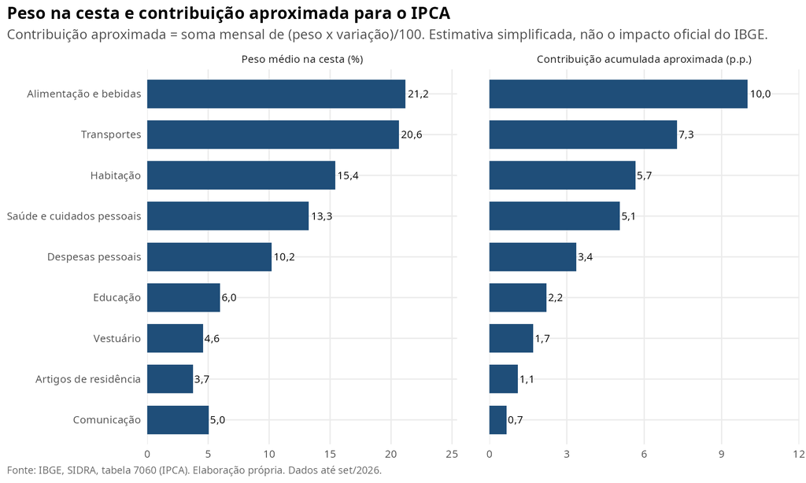

Peso médio e contribuição aproximada por grupo

| Grupo | Peso médio (%) | Contribuição acum. aprox. (p.p.) | Participação (%) | Aumento acumulado (%) |
| --- | --- | --- | --- | --- |
| Alimentação e bebidas | 21,2 | 10,0 | 27,0 | 60,7 |
| Transportes | 20,6 | 7,3 | 19,6 | 41,6 |
| Habitação | 15,4 | 5,7 | 15,3 | 43,8 |
| Saúde e cuidados pessoais | 13,3 | 5,1 | 13,6 | 46,7 |
| Despesas pessoais | 10,2 | 3,4 | 9,1 | 39,5 |
| Educação | 6,0 | 2,2 | 6,0 | 45,1 |
| Vestuário | 4,6 | 1,7 | 4,6 | 45,6 |
| Artigos de residência | 3,7 | 1,1 | 3,0 | 33,5 |
| Comunicação | 5,0 | 0,7 | 1,8 | 13,8 |

Peso, variação e contribuição respondem a perguntas diferentes. O peso diz quanto do orçamento o grupo representa; a variação diz quanto seus preços subiram; a contribuição combina as duas coisas. Comunicação, por exemplo, tem peso médio de 5,0%, mas contribuiu pouco porque seus preços subiram pouco.

**Limitação importante.** A estimativa soma, mês a mês, `peso × variação / 100`. Por mês, ela reproduz o IPCA geral com resíduo máximo de 0,007 p.p. Porém, somar contribuições mensais não equivale à contribuição composta oficial do IBGE: a soma de todos os grupos aqui é de 37,0 p.p., enquanto o aumento acumulado composto do IPCA é de 44,7%. A coluna “Participação” serve para comparar grupos entre si, mas os valores em p.p. não somam o acumulado composto.

A correlação de Spearman entre peso médio e aumento acumulado é de 0,48, calculada com apenas 9 grupos. É uma medida descritiva, sem força para sustentar conclusões.

## Investigação das hipóteses

Para ir além da descrição, as três hipóteses foram transformadas em **previsões que podem falhar**, com limiares definidos antes de olhar os resultados (são escolhas de julgamento, não regras estatísticas; estão em `R/07_hipoteses.R`). Foram coletados dados adicionais: IPCA por subgrupo e item (IBGE/SIDRA, tabela 7060) e séries do Banco Central (SGS: câmbio, preços livres e monitorados). **“Consistente” significa que os dados não contradizem a hipótese; não significa que ela esteja provada.**

| Hipótese | Veredito | Observação |
| --- | --- | --- |
| H1 - choques de oferta/custos em alimentos e transportes nos picos | consistente (parte descritiva; causa não testada) | Testado: concentração da alta em poucos itens e peso de Alimentação+Transportes. Não testado: a causa (oferta/custos), que exige evidência externa. |
| H2 - Educação em fevereiro e reajuste de mensalidades | consistente | Testado com os próprios dados do IBGE (itens e subgrupos). A confirmação do mecanismo (mensalidades) depende da metodologia do IBGE. |
| H3 - câmbio, preços livres e administrados | indício descritivo de relação com o câmbio (sem causalidade) | Apenas descritivo: ~70 correlações simultâneas, 81 meses, sem controles. Não prova causalidade. |

### H2: Educação em fevereiro e reajuste de mensalidades

**Previsão.** Se o salto vem de reajustes de mensalidades, fevereiro deve ser o mês de maior alta de Educação na maioria dos anos, deve responder pela maior parte da alta anual e deve se concentrar no item de cursos regulares.

| Critério | Resultado | Limiar | Atendido |
| --- | --- | --- | --- |
| Proporção de anos em que fevereiro é o mês de maior alta de Educação | 100% | 80% | Sim |
| Mediana da razão (alta de fevereiro / alta do ano), anos completos | 76% | 50% | Sim |
| Participação do item ‘Cursos regulares’ na contribuição de fevereiro (itens de Educação) | 90% | 70% | Sim |

Fevereiro foi o mês de maior alta de Educação em 100% dos anos; a mediana da razão entre a alta de fevereiro e a alta do ano foi de 76%; e o item “Cursos regulares” respondeu por 90% da contribuição de fevereiro entre os itens de Educação. Veredito: **consistente**.

Itens de Educação

| Item | Peso médio (%) | Var. média em fev. (%) | Var. média nos demais meses (%) | Participação na contribuição de fev. |
| --- | --- | --- | --- | --- |
| Cursos regulares | 4,5 | 5,68 | -0,00 | 90% |
| Cursos diversos | 0,8 | 2,75 | 0,18 | 8% |
| Leitura | 0,5 | 0,84 | 0,42 | 2% |
| Papelaria | 0,1 | 0,30 | 0,42 | 0% |

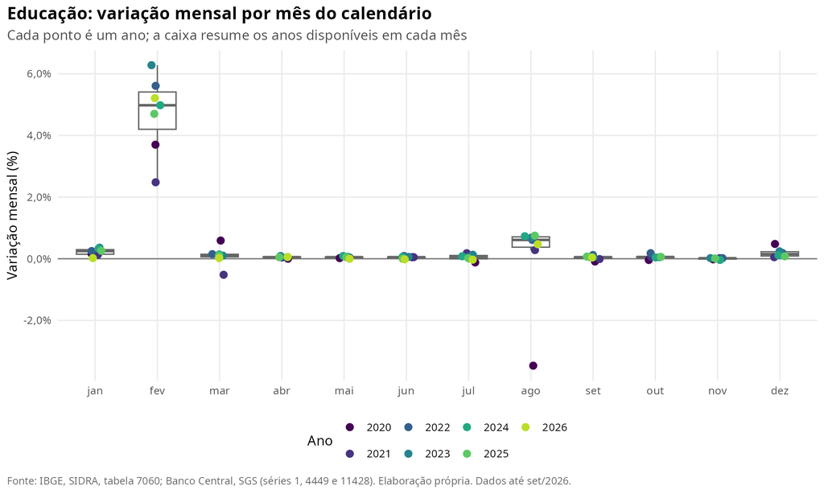

Educação: variação mensal por mês do calendário

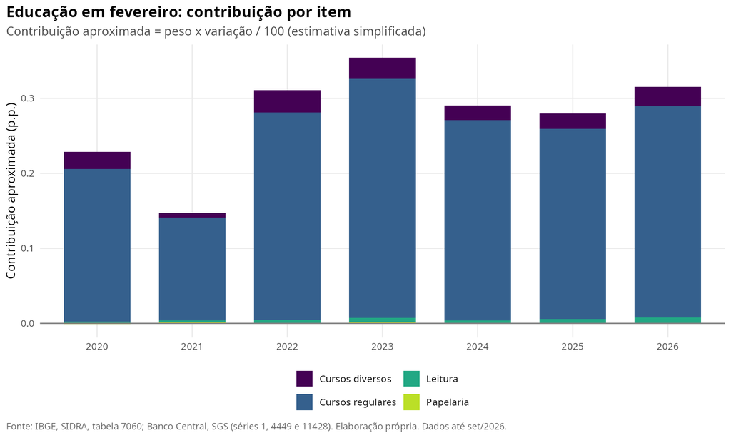

Contribuição dos itens de Educação em fevereiro

O teste usa só dados do IBGE. Ele mostra *onde* o salto acontece, mas o mecanismo (reajuste de mensalidades) deve ser confirmado na metodologia do IBGE.

### H1: choques de oferta e de custos nos picos

**Previsão.** Nos cinco maiores picos do IPCA, a alta deve estar concentrada em poucos itens, e Alimentação e Transportes devem explicar a maior parte dela.

| Mês | Alta do IPCA (%) | 5 maiores itens (% da alta) | Alimentação + Transportes (% da alta) |
| --- | --- | --- | --- |
| dez/2020 | 1,35 | 60 | 47 |
| set/2021 | 1,16 | 64 | 51 |
| out/2021 | 1,25 | 56 | 64 |
| mar/2022 | 1,62 | 60 | 72 |
| fev/2025 | 1,31 | 87 | 21 |

Em 100% dos picos os cinco maiores itens explicam pelo menos metade da alta, e em 60% dos picos Alimentação e Transportes explicam pelo menos metade (limiar de 60% dos picos em cada critério). Veredito: **consistente (parte descritiva; causa não testada)**.

**Verificações adicionais (robustez).** A fatia das contribuições positivas explicada pelos cinco maiores itens foi, em mediana, de 59% nos picos e de 58% em todos os meses; se os valores forem próximos, a concentração nos picos não é uma característica especial deles. Por grupo, a maior participação média na alta dos picos foi de Transportes; Habitação; Alimentação e bebidas (29%; 28%; 22%). Portanto, o critério “Alimentação + Transportes” pode ser atendido principalmente por um dos dois grupos; veja os itens líderes abaixo antes de concluir.

Três itens de maior contribuição em cada pico

| Mês | Posição | Item | Grupo | Contribuição (p.p.) |
| --- | --- | --- | --- | --- |
| dez/2020 | 1 | Energia elétrica residencial | Habitação | 0,40 |
| dez/2020 | 2 | Transporte público | Transportes | 0,15 |
| dez/2020 | 3 | Carnes | Alimentação e bebidas | 0,11 |
| set/2021 | 1 | Energia elétrica residencial | Habitação | 0,31 |
| set/2021 | 2 | Combustíveis (veículos) | Transportes | 0,18 |
| set/2021 | 3 | Transporte público | Transportes | 0,11 |
| out/2021 | 1 | Combustíveis (veículos) | Transportes | 0,24 |
| out/2021 | 2 | Transporte público | Transportes | 0,18 |
| out/2021 | 3 | Veículo próprio | Transportes | 0,13 |
| mar/2022 | 1 | Combustíveis (veículos) | Transportes | 0,51 |
| mar/2022 | 2 | Tubérculos, raízes e legumes | Alimentação e bebidas | 0,14 |
| mar/2022 | 3 | Veículo próprio | Transportes | 0,14 |
| fev/2025 | 1 | Energia elétrica residencial | Habitação | 0,56 |
| fev/2025 | 2 | Cursos regulares | Educação | 0,25 |
| fev/2025 | 3 | Combustíveis (veículos) | Transportes | 0,18 |

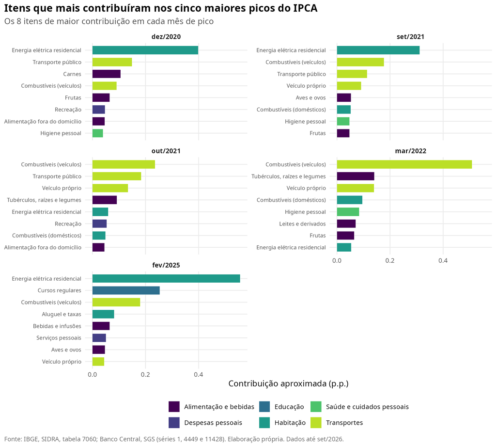

Principais itens nos cinco maiores picos do IPCA

Este teste verifica a **concentração** da alta, não a **causa**. Afirmar que houve choque de oferta ou de custos exige evidência externa (notas do IBGE de cada mês, preços de commodities e combustíveis), que não foi coletada.

### H3: câmbio, preços livres e administrados

Aqui a análise é apenas descritiva. Os preços monitorados (administrados) acumularam 44,7% no período e os preços livres, 44,5%, contra 44,7% do IPCA geral. No acumulado do período os dois ficaram muito próximos, mas dentro de um mesmo ano a diferença entre eles chegou a 13,2 p.p. Explicar essas divergências exige informação sobre os itens monitorados e sobre eventuais medidas de política de preços, que não foram analisadas aqui.

Inflação acumulada (composta) por ano

| Ano | Meses | IPCA geral (%) | Livres (%) | Monitorados (%) |
| --- | --- | --- | --- | --- |
| 2020 | 12 | 4,52 | 5,19 | 2,61 |
| 2021 | 12 | 10,06 | 7,67 | 16,90 |
| 2022 | 12 | 5,78 | 9,37 | -3,83 |
| 2023 | 12 | 4,62 | 3,13 | 9,13 |
| 2024 | 12 | 4,83 | 4,89 | 4,66 |
| 2025 | 12 | 4,26 | 3,90 | 5,28 |
| 2026 | 9 | 3,95 | 3,80 | 4,31 |
| Período todo | 81 | 44,65 | 44,51 | 44,70 |

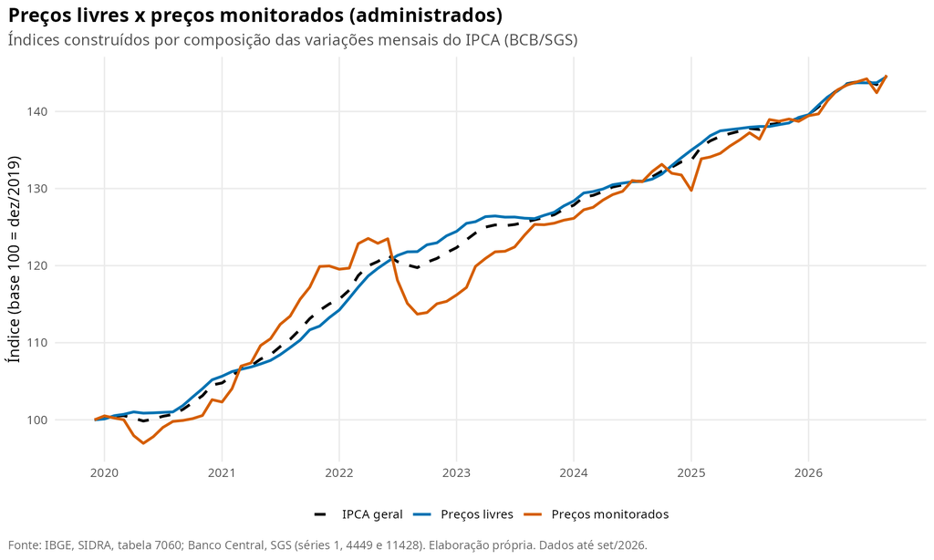

Preços livres e monitorados

Foram calculadas correlações entre a inflação mensal de cada grupo e a variação mensal do câmbio (média mensal do dólar), com defasagens de 0 a 6 meses. Das 70 correlações, 13 ficaram acima do limiar aproximado de ruído (2/√n), contra cerca de 3,5 esperadas só por acaso (e os grupos são correlacionados entre si, então o número efetivo de testes independentes é menor). A maior correlação absoluta foi 0,34, entre **Alimentação e bebidas** e o câmbio defasado em 6 meses, o que corresponde a cerca de 12% da variação mensal do grupo. Como essa é a maior defasagem testada, o resultado merece cautela: a relação pode se estender a defasagens maiores ou ser acaso. Veredito: **indício descritivo de relação com o câmbio (sem causalidade)**.

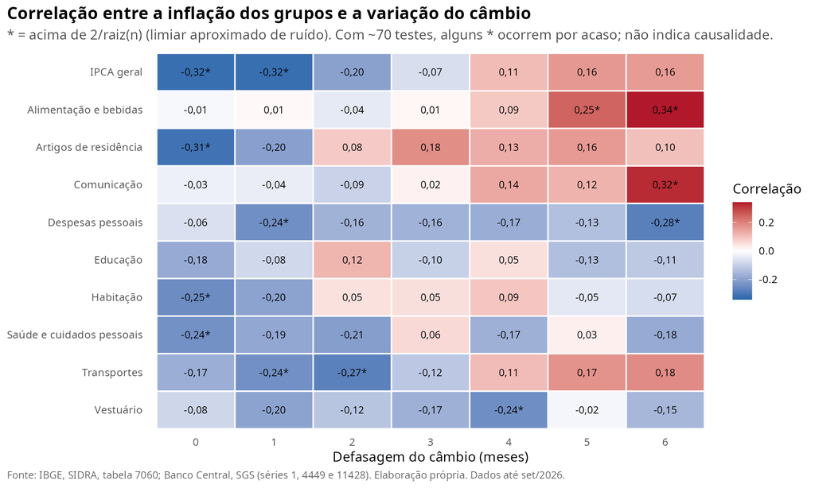

Correlação entre inflação dos grupos e variação do câmbio

Com 81 meses, muitos testes simultâneos, sem controles e com variáveis correlacionadas entre si, esse resultado **não identifica causalidade**.

## Agregados monetários (M2, M3 e M4) e inflação

Esta seção investiga se o crescimento dos meios de pagamento amplos acompanha ou antecede o IPCA. Três conceitos são mantidos separados ao longo do texto: **associação estatística** (as séries se movem juntas), **precedência temporal** (uma série se move antes da outra) e **causalidade econômica** (uma série provoca a outra). Os métodos usados aqui podem mostrar as duas primeiras, mas não a terceira.

### Dados e definições

| Agregado | Definição (Banco Central) | Série SGS |
| --- | --- | --- |
| M2 | M1 + depósitos de poupança + títulos privados emitidos por instituições depositárias | 27810 |
| M3 | M2 + quotas de fundos de investimento depositários + operações compromissadas com títulos públicos e privados | 27813 |
| M4 | M3 + títulos públicos emitidos pelo Governo Federal | 27815 |

São as séries “Novo” dos meios de pagamento amplos (BCB/SGS): mensais, saldo em final de período, em milhares de reais correntes, com revisão histórica desde dez/2001. Os dados vão até ago/2026; a análise com o IPCA cobre jan/2020 a ago/2026, o período do IPCA já usado no projeto. Como **M2 ⊂ M3 ⊂ M4**, os agregados têm componentes sobrepostos: seus resultados não são evidências independentes entre si, e nenhum modelo inclui dois agregados ao mesmo tempo. As séries estão completas (sem meses faltando) e respeitam M2 ≤ M3 ≤ M4 em todos os meses.

### Evolução dos agregados

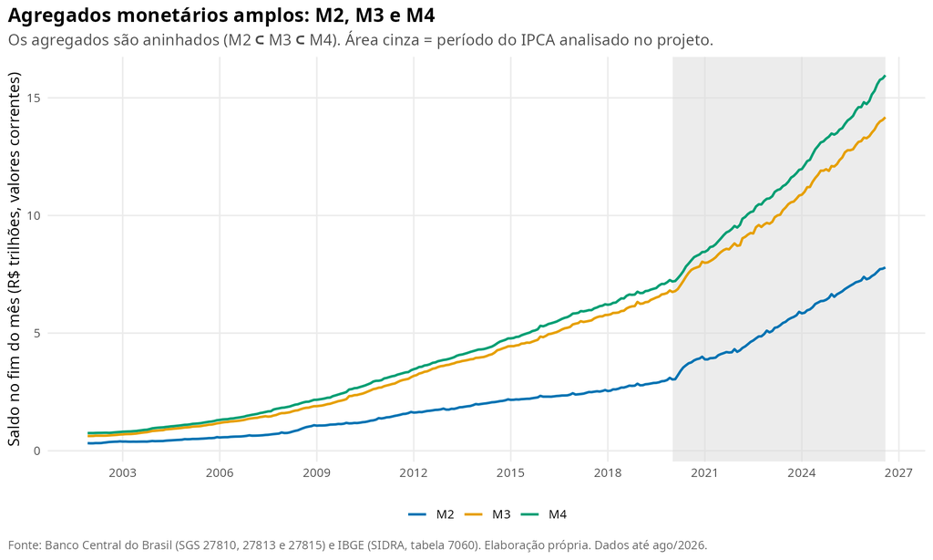

Saldos de M2, M3 e M4

Crescimento dos agregados e IPCA na janela da análise

| Agregado | Saldo final (R$ tri) | Crescimento nominal na janela (%) | IPCA na janela (%) | Crescimento real (%) | Média mensal (%) | Máx. em 12 meses (%) | Último 12 meses (%) |
| --- | --- | --- | --- | --- | --- | --- | --- |
| M2 | 7,79 | 151,4 | 43,5 | 75,2 | 1,17 | 31,2 (out/2020) | 10,0 |
| M3 | 14,17 | 108,0 | 43,5 | 45,0 | 0,92 | 18,3 (jan/2021) | 10,6 |
| M4 | 15,96 | 120,0 | 43,5 | 53,3 | 0,99 | 18,2 (fev/2021) | 12,1 |

O crescimento “real” é o nominal deflacionado pelo IPCA acumulado do mesmo período; descreve o poder de compra do saldo, não uma relação de causa com a inflação.

### Crescimento mensal e em 12 meses frente ao IPCA

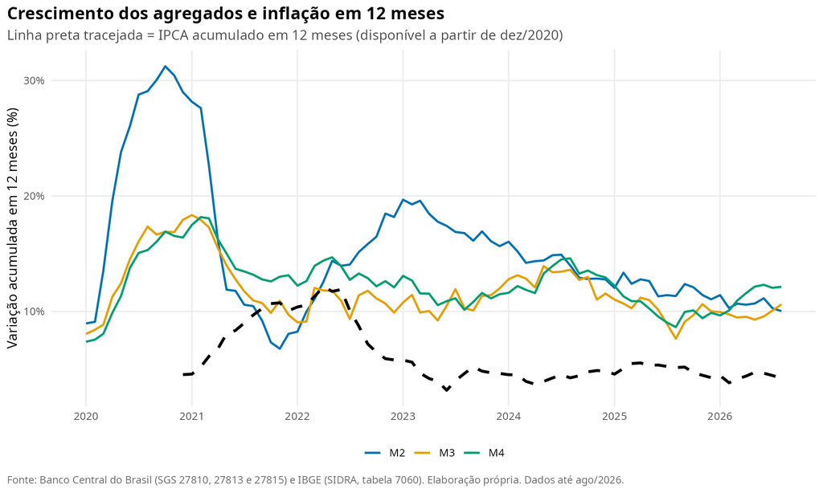

Crescimento em 12 meses dos agregados e IPCA em 12 meses

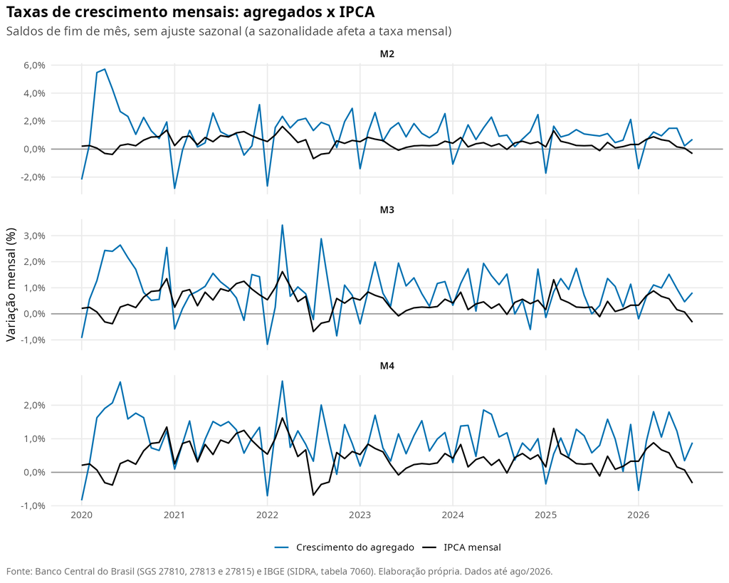

Taxas mensais dos agregados e do IPCA

As taxas em 12 meses suavizam o ruído e a sazonalidade, mas **sobrepõem janelas** (cada mês entra em doze taxas), o que cria forte autocorrelação e reduz muito o número efetivo de observações. Por isso elas são usadas para descrever, e a inferência se apoia nas taxas mensais. Os saldos não são dessazonalizados, então a taxa mensal pode conter efeitos sazonais.

### Correlações com defasagens de 3, 6, 9 e 12 meses

Cada célula é a correlação entre o crescimento do agregado em *t − k* e o IPCA em *t* (k = 0 é a referência contemporânea). O asterisco (*) marca correlações acima do limiar aproximado de ruído, 2/√n (com n efetivo ≈ n/12 nas taxas em 12 meses).

Taxas mensais: correlação de Pearson

| Agregado | k = 0 | k = 3 | k = 6 | k = 9 | k = 12 |
| --- | --- | --- | --- | --- | --- |
| M2 | -0,10 | -0,01 | 0,14 | 0,14 | 0,14 |
| M3 | 0,01 | -0,00 | 0,17 | 0,16 | 0,11 |
| M4 | 0,09 | 0,08 | 0,26* | 0,19 | 0,12 |

Taxas em 12 meses (descritiva; observações sobrepostas)

| Agregado | k = 0 | k = 3 | k = 6 | k = 9 | k = 12 |
| --- | --- | --- | --- | --- | --- |
| M2 | -0,33 | -0,30 | -0,12 | 0,20 | 0,51 |
| M3 | -0,10 | 0,05 | 0,25 | 0,54 | 0,73 |
| M4 | 0,32 | 0,39 | 0,52 | 0,67 | 0,65 |

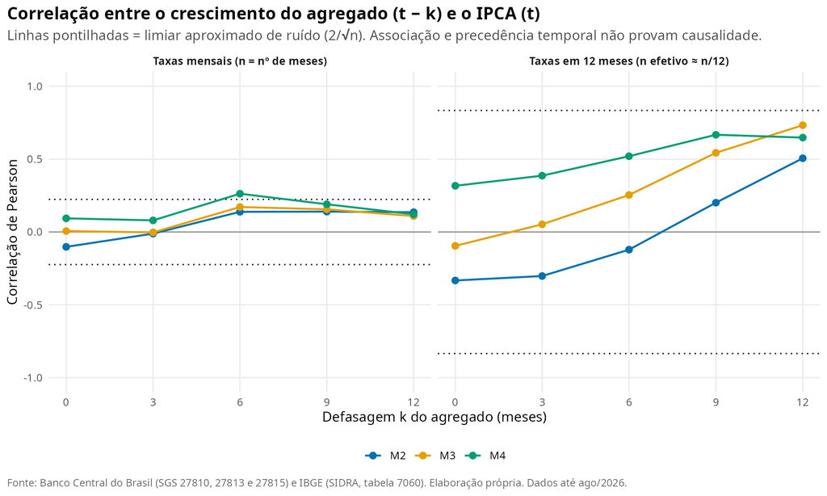

Correlação por defasagem

Entre as taxas mensais com defasagem positiva, 1 de 12 correlações superaram o limiar de ruído (cerca de 0,6 esperadas só por acaso, e os agregados são correlacionados entre si). A maior correlação absoluta foi 0,26, para o **M4** com defasagem de 6 meses (n = 80), o que corresponde a cerca de 6,9% da variância linear do IPCA mensal.

Taxas mensais: correlação por subperíodo

| Período | Agregado | k = 3 | k = 6 | k = 9 | k = 12 |
| --- | --- | --- | --- | --- | --- |
| 2020-2022 | M2 | -0,01 | 0,15 | 0,10 | 0,22 |
| 2020-2022 | M3 | 0,17 | 0,14 | 0,10 | 0,12 |
| 2020-2022 | M4 | 0,24 | 0,28 | 0,11 | 0,15 |
| 2023 em diante | M2 | -0,13 | 0,05 | 0,25 | -0,06 |
| 2023 em diante | M3 | -0,45 | 0,19 | 0,23 | 0,08 |
| 2023 em diante | M4 | -0,31 | 0,16 | 0,31 | 0,06 |

Se o sinal ou o tamanho das correlações muda entre subperíodos (36 a 44 observações cada), a relação não é estável no tempo, o que enfraquece qualquer leitura causal simples. As taxas mensais dos agregados são correlacionadas entre si (entre 0,69 e 0,84), consequência direta da sobreposição de componentes.

### Estacionariedade e regressões exploratórias

Antes de regredir, uma triagem de estacionariedade (Dickey-Fuller aumentado, com constante e 3 defasagens). O teste tem baixo poder com amostras deste tamanho; serve só como alerta.

| Série | n | t (ADF) | Crítico 5% | Rejeita raiz unitária |
| --- | --- | --- | --- | --- |
| ipca_m | 80 | -4,02 | -2,86 | Sim |
| ipca_12m | 69 | -1,49 | -2,86 | Não |
| cresc_mensal_M2 | 80 | -4,75 | -2,86 | Sim |
| cresc_mensal_M3 | 80 | -4,51 | -2,86 | Sim |
| cresc_mensal_M4 | 80 | -4,84 | -2,86 | Sim |
| cresc_12m_M2 | 80 | -3,13 | -2,86 | Sim |
| cresc_12m_M3 | 80 | -2,25 | -2,86 | Não |
| cresc_12m_M4 | 80 | -2,98 | -2,86 | Sim |
| cambio_var | 80 | -6,40 | -2,86 | Sim |

Séries em que **não** se rejeitou raiz unitária a 5%: ipca_12m, cresc_12m_M3. Regressões entre séries não estacionárias podem ser espúrias; por isso os modelos usam as **taxas mensais** (variações), não os níveis nem as taxas em 12 meses.

Os modelos explicam o IPCA mensal pelo crescimento mensal do agregado defasado em *k* meses. O modelo 1 é simples; o modelo 2 acrescenta o câmbio defasado e o IPCA do mês anterior como controles parciais. Os erros-padrão são robustos a autocorrelação e heteroscedasticidade (Newey-West), com p-valores aproximados pela distribuição normal.

Coeficiente do crescimento mensal do agregado (p.p. de IPCA por p.p. de crescimento)

| Modelo | Agregado | Defasagem (meses) | n | Coeficiente | EP (HAC) | p (aprox.) | R² |
| --- | --- | --- | --- | --- | --- | --- | --- |
| 1: simples | M2 | 3 | 80 | -0,003 | 0,023 | 0,885 | 0,000 |
| 2: com câmbio e IPCA(t-1) | M2 | 3 | 77 | 0,031 | 0,026 | 0,236 | 0,284 |
| 1: simples | M2 | 6 | 80 | 0,040 | 0,035 | 0,253 | 0,019 |
| 2: com câmbio e IPCA(t-1) | M2 | 6 | 74 | 0,039 | 0,036 | 0,278 | 0,262 |
| 1: simples | M2 | 9 | 80 | 0,042 | 0,036 | 0,252 | 0,020 |
| 2: com câmbio e IPCA(t-1) | M2 | 9 | 71 | 0,018 | 0,033 | 0,585 | 0,249 |
| 1: simples | M2 | 12 | 80 | 0,039 | 0,020 | 0,053 | 0,018 |
| 2: com câmbio e IPCA(t-1) | M2 | 12 | 68 | 0,015 | 0,019 | 0,432 | 0,229 |
| 1: simples | M3 | 3 | 80 | -0,001 | 0,045 | 0,976 | 0,000 |
| 2: com câmbio e IPCA(t-1) | M3 | 3 | 77 | 0,016 | 0,050 | 0,747 | 0,276 |
| 1: simples | M3 | 6 | 80 | 0,083 | 0,057 | 0,150 | 0,029 |
| 2: com câmbio e IPCA(t-1) | M3 | 6 | 74 | 0,081 | 0,046 | 0,081 | 0,275 |
| 1: simples | M3 | 9 | 80 | 0,075 | 0,050 | 0,131 | 0,024 |
| 2: com câmbio e IPCA(t-1) | M3 | 9 | 71 | 0,044 | 0,048 | 0,359 | 0,254 |
| 1: simples | M3 | 12 | 80 | 0,051 | 0,032 | 0,110 | 0,012 |
| 2: com câmbio e IPCA(t-1) | M3 | 12 | 68 | 0,002 | 0,037 | 0,959 | 0,226 |
| 1: simples | M4 | 3 | 80 | 0,049 | 0,069 | 0,472 | 0,006 |
| 2: com câmbio e IPCA(t-1) | M4 | 3 | 77 | 0,062 | 0,055 | 0,261 | 0,284 |
| 1: simples | M4 | 6 | 80 | 0,165 | 0,072 | 0,023 | 0,069 |
| 2: com câmbio e IPCA(t-1) | M4 | 6 | 74 | 0,139 | 0,061 | 0,023 | 0,296 |
| 1: simples | M4 | 9 | 80 | 0,122 | 0,070 | 0,080 | 0,036 |
| 2: com câmbio e IPCA(t-1) | M4 | 9 | 71 | 0,050 | 0,068 | 0,462 | 0,251 |
| 1: simples | M4 | 12 | 80 | 0,075 | 0,053 | 0,158 | 0,015 |
| 2: com câmbio e IPCA(t-1) | M4 | 12 | 68 | 0,044 | 0,049 | 0,374 | 0,231 |

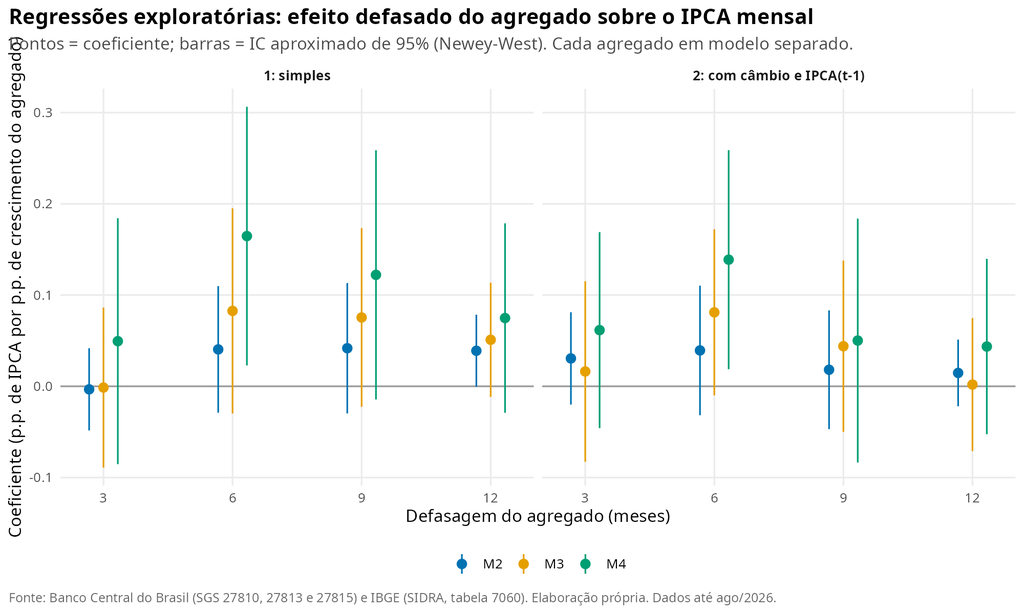

Coeficientes das regressões

2 de 24 coeficientes tiveram p aproximado abaixo de 0,05, contra cerca de 1,2 esperados só por acaso (e as especificações não são independentes). O R² mais alto foi de 0,296.

Para a **precedência temporal**, foram feitos testes do tipo Granger (teste F de que as defasagens de uma série acrescentam informação à previsão da outra), nos dois sentidos, com 3 e 6 defasagens.

| Direção | Agregado | Defasagens | n | Estatística F | p-valor |
| --- | --- | --- | --- | --- | --- |
| agregado -> IPCA | M2 | 3 | 77 | 4,99 | 0,003 |
| agregado -> IPCA | M2 | 6 | 74 | 2,16 | 0,059 |
| agregado -> IPCA | M3 | 3 | 77 | 2,15 | 0,102 |
| agregado -> IPCA | M3 | 6 | 74 | 1,29 | 0,276 |
| agregado -> IPCA | M4 | 3 | 77 | 1,89 | 0,139 |
| agregado -> IPCA | M4 | 6 | 74 | 1,53 | 0,185 |
| IPCA -> agregado | M2 | 3 | 77 | 0,78 | 0,511 |
| IPCA -> agregado | M2 | 6 | 74 | 1,10 | 0,370 |
| IPCA -> agregado | M3 | 3 | 77 | 0,71 | 0,550 |
| IPCA -> agregado | M3 | 6 | 74 | 1,01 | 0,426 |
| IPCA -> agregado | M4 | 3 | 77 | 0,44 | 0,724 |
| IPCA -> agregado | M4 | 6 | 74 | 2,05 | 0,073 |

No sentido agregado → IPCA, 1 de 6 testes ficaram abaixo de 0,05; no sentido IPCA → agregado, 0 de 6. A “causalidade de Granger” é apenas capacidade preditiva incremental: não identifica causa econômica, e uma terceira variável (por exemplo, a taxa de juros ou o câmbio) pode explicar os dois movimentos.

### Como interpretar estes resultados

- **Associação.** Correlações e coeficientes medem comovimento linear. Podem surgir de um fator comum, de coincidência em amostras curtas ou de testes múltiplos.
- **Precedência temporal.** Um agregado que “antecede” o IPCA estatisticamente é compatível com, mas não prova, um efeito monetário. A própria inflação pode preceder o crescimento nominal dos agregados (a demanda por moeda nominal se ajusta aos preços); por isso o teste foi feito nos dois sentidos.
- **Causalidade econômica.** Exigiria identificação (por exemplo, choques monetários exógenos, instrumentos ou modelos estruturais) e controle de outros determinantes. Isso está fora do escopo deste projeto.

**Possíveis fatores de confusão (não controlados, ou controlados só em parte):** taxa básica de juros e operações compromissadas (que compõem o M3); política fiscal e emissão de títulos públicos (que compõem o M4); câmbio (apenas um controle parcial no modelo 2); atividade econômica e hiato do produto; choques de oferta em alimentos, energia e combustíveis; preços administrados; expectativas de inflação; o choque da pandemia, que pode ter alterado a demanda por ativos líquidos e a velocidade de circulação da moeda; migração de recursos entre poupança, fundos e títulos, que muda a composição entre M2, M3 e M4 sem alterar a liquidez total; e a sazonalidade das taxas mensais.

**Limitações específicas.** A amostra do IPCA do projeto é curta (a partir de jan/2020) e dominada por poucos episódios; as correlações têm intervalo largo; M2, M3 e M4 não são independentes; os modelos são lineares e não consideram mudanças de regime; as taxas em 12 meses sobrepõem janelas; e o conjunto de testes é grande em relação ao tamanho da amostra.

## Principais resultados

- **Maiores aumentos acumulados:** Alimentação e bebidas; Saúde e cuidados pessoais; Vestuário.
- **Menores aumentos acumulados:** Comunicação; Artigos de residência; Despesas pessoais.
- **Alimentação e bebidas** encareceu 16,1 p.p. a mais que o IPCA geral no acumulado do período.
- **Picos:** a maior variação mensal do IPCA geral foi de 1,62% (mar/2022) e a menor, de -0,68% (jul/2022).
- **Contribuição aproximada:** os três grupos com maior contribuição foram Alimentação e bebidas; Transportes; Habitação, responsáveis por 62% do total estimado.

## Conclusões econômicas

**O que os dados mostram.** Alimentação e bebidas foi o grupo que mais encareceu no período e também o de maior contribuição estimada para a inflação, combinando alta variação e alto peso. As cinco maiores variações mensais do IPCA geral ocorreram em dez/2020, set/2021, out/2021, mar/2022 e fev/2025, e o acumulado em 12 meses chegou a 12,13% em abr/2022. Comunicação ficou muito abaixo dos demais grupos.

**Hipóteses (testadas de forma exploratória).** Os resultados completos estão na seção “Investigação das hipóteses”; os vereditos significam apenas que os dados não contradizem (ou contradizem) cada hipótese:

- **H1, choques de oferta e de custos nos picos:** consistente (parte descritiva; causa não testada). A causa não foi testada; exige evidência externa.
- **H2, Educação em fevereiro:** consistente. O mecanismo de reajuste de mensalidades deve ser confirmado na metodologia do IBGE.
- **H3, câmbio, preços livres e administrados:** indício descritivo de relação com o câmbio (sem causalidade). Análise descritiva, sem controle de outros fatores.

**Agregados monetários.** Na janela analisada, 1 de 12 correlações defasadas (taxas mensais) superaram o limiar de ruído e 2 de 24 coeficientes de regressão tiveram p aproximado abaixo de 0,05 (cerca de 1,2 esperados por acaso). Esses resultados descrevem associação e precedência estatística; não permitem afirmar que a expansão monetária causou (ou não causou) a inflação.

Este relatório observa associações nos dados e não estabelece causalidade. Além disso, o IPCA é um índice agregado, calculado para famílias urbanas com rendimento de 1 a 40 salários mínimos; a inflação vivida por cada família depende da composição de seus gastos. Uma família que destina grande parte do orçamento a alimentação teve experiência diferente da média.

## Limitações

- Análise descritiva: não permite concluir causas, e correlações não implicam causalidade.
- A série cobre poucos anos e inclui choques atípicos; padrões sazonais e a correlação entre grupos (n = 9) são frágeis.
- A contribuição é uma aproximação simplificada, não o impacto oficial do IBGE.
- Grupos são agregados heterogêneos; médias escondem variações entre itens, subgrupos e regiões.
- Na análise monetária, a amostra é curta, os agregados M2, M3 e M4 são sobrepostos, as séries não são dessazonalizadas e há muitos testes simultâneos; os resultados são exploratórios e não identificam causalidade.
- Os limiares dos testes de hipóteses são escolhas de julgamento; com outros limiares os vereditos podem mudar. A contribuição por item usa a mesma aproximação simplificada.
- Os dados são de um único momento de coleta (19/10/2026) e podem ser revistos ou ampliados pelo IBGE.

## Referências

- IBGE. SIDRA, Tabela 7060: IPCA. https://sidra.ibge.gov.br/tabela/7060
- Banco Central do Brasil. Sistema Gerenciador de Séries Temporais (SGS), séries 1, 4449 e 11428. https://dadosabertos.bcb.gov.br/
- Banco Central do Brasil. Meios de pagamento amplos (saldo em final de período) - Novo: M2 (SGS 27810), M3 (SGS 27813) e M4 (SGS 27815). Catálogo de dados abertos: https://dadosabertos.bcb.gov.br/
- IBGE. IPCA, Índice Nacional de Preços ao Consumidor Amplo. https://www.ibge.gov.br/estatisticas/economicas/precos-e-custos/9256-indice-nacional-de-precos-ao-consumidor-amplo.html